# Labs 3 & 4: Linear Regression and `ggplot2`

Part 2

Author

Connor Wiegand

### Data

Let’s start by loading some data. The following will load the `mtcars` dataset into your workspace. You can see details by running the `?mtcars` command below.

```r
library(tidyverse)
library(magrittr)
data(mtcars)
mtcars
?mtcars
```

## Basic Visualization and Linear Regression

Let’s start by looking at the data. The `geom_point` function will help us plot simple points in the data. I want to look at MPG and weight:

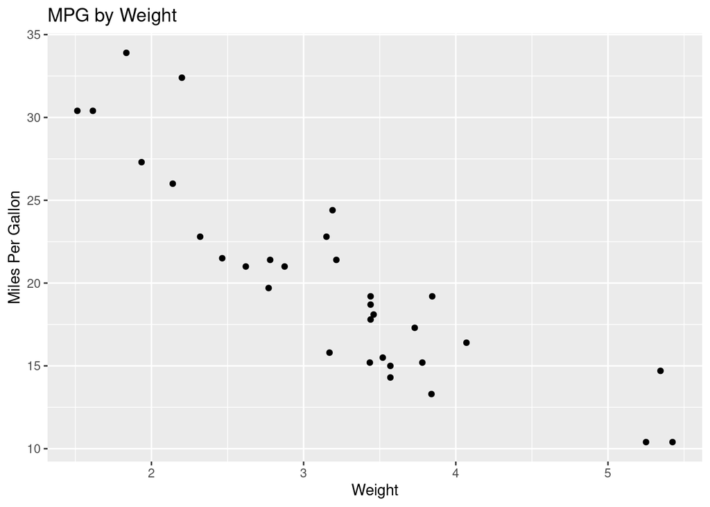

```r
mtcars %>%
   ggplot() +
   geom_point(aes(x = wt, y = mpg)) +
   labs(x = "Weight", y = "Miles Per Gallon", title = "MPG by Weight")
```

It seems like there is a relationship here. Let’s use linear regression to analyze it.

```r
mpg_on_weight <- mtcars %>% lm(mpg ~ wt, data = .)
mpg_on_weight
```

```
Call:
lm(formula = mpg ~ wt, data = .)

Coefficients:
(Intercept)           wt
     37.285       -5.344
```

There are a couple things we can do to this `lm` object to output it in a prettier and/or more usable format:

- `summary()`
  - this option outputs the results in a nice, verbose format

```r
mpg_on_weight %>% summary()
```

```
Call:
lm(formula = mpg ~ wt, data = .)

Residuals:
    Min      1Q  Median      3Q     Max
-4.5432 -2.3647 -0.1252  1.4096  6.8727

Coefficients:
            Estimate Std. Error t value Pr(>|t|)
(Intercept)  37.2851     1.8776  19.858  < 2e-16 ***
wt           -5.3445     0.5591  -9.559 1.29e-10 ***
---
Signif. codes:  0 '***' 0.001 '**' 0.01 '*' 0.05 '.' 0.1 ' ' 1

Residual standard error: 3.046 on 30 degrees of freedom
Multiple R-squared:  0.7528,    Adjusted R-squared:  0.7446
F-statistic: 91.38 on 1 and 30 DF,  p-value: 1.294e-10
```

- `broom::tidy()`
  - outputs a `tbl_df`, which may come in handy if we need to access parts of this model using tidy syntax.

```r
mpg_on_weight %>% broom::tidy()
```

```
# A tibble: 2 × 5
  term        estimate std.error statistic  p.value
  <chr>          <dbl>     <dbl>     <dbl>    <dbl>
1 (Intercept)    37.3      1.88      19.9  8.24e-19
2 wt             -5.34     0.559     -9.56 1.29e-10
```

Now that we have a model in hand, let’s visualize it. I have outlined three different ways below:

**Method 1**

First, let’s take the original dataset, tack the fitted values from the model onto it, and call it something new:

```r
cars_df <- mtcars %>% mutate(fitted = mpg_on_weight$fitted.values)
```

Now, let’s pipe this new data frame into a `ggplot` call with `geom_line`

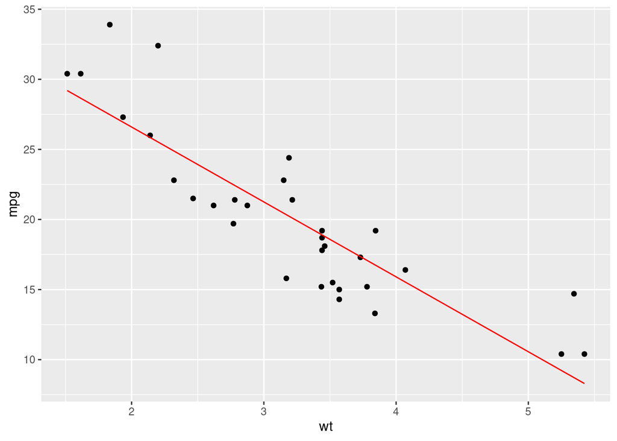

```r
cars_df %>%
   ggplot(aes(x = wt, y = mpg)) +
   geom_point() +
   geom_line(aes(y = fitted), col = "red")
```

**Method 2**

In this example, we take the coefficients directly from the model. Note that this is not very `tidy` of us[^1]

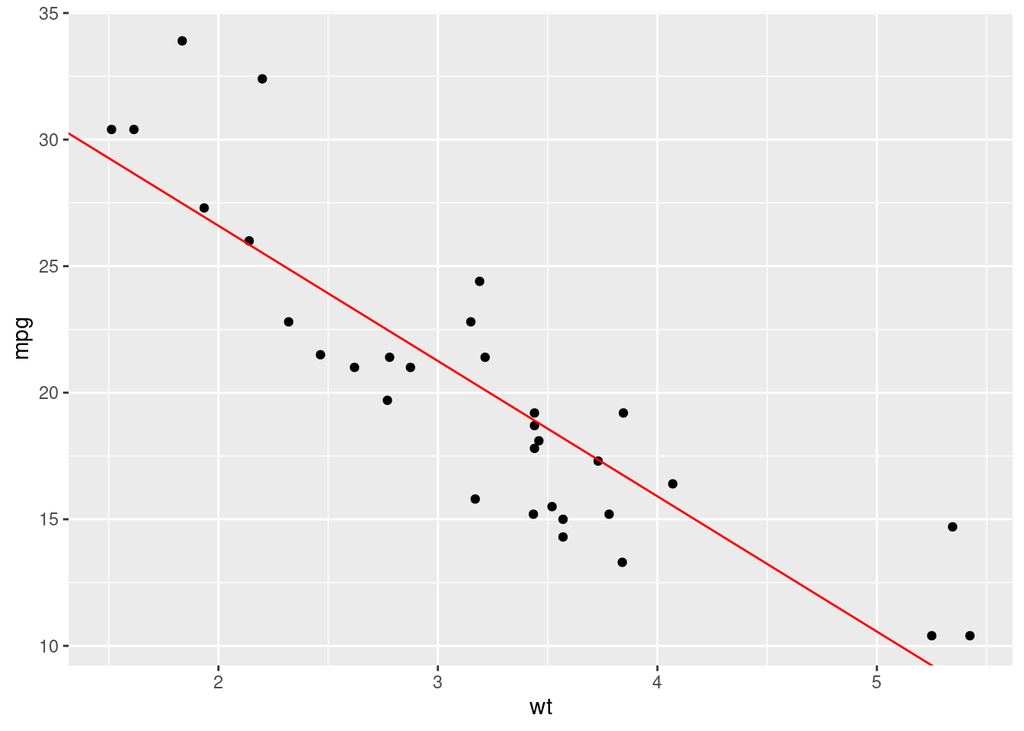

```r
mtcars %>%
   ggplot(aes(x = wt, y = mpg)) +
   geom_point() +
   geom_abline(
      intercept = mpg_on_weight$coefficients[1],
      slope = mpg_on_weight$coefficients[2],
      col = "red")
```

**Method 3**

If all we care about is visualization (rather than actual data values), we can use `geom_smooth`:

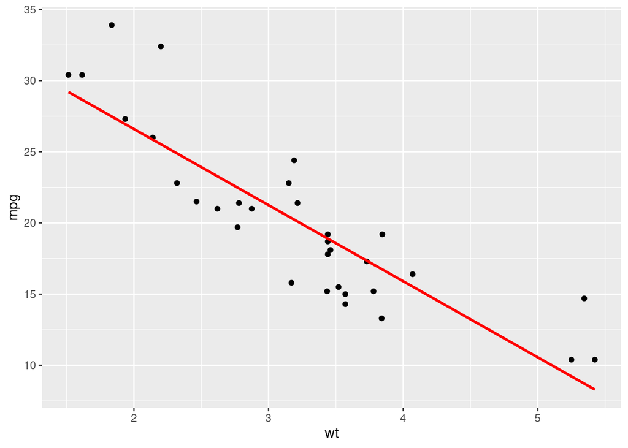

```r
mtcars %>%
   ggplot(aes(x = wt, y = mpg)) +
   geom_point() +
   geom_smooth(method = "lm", se = F, col ="red")
```

We can even visualize confidence intervals by leaving out `se = F`. I’ll leave this for you to do.

**Caution**

Note the error produced here:

```r
mtcars %>%
   ggplot() +
   geom_point(aes(x = wt, y = mpg)) +
   geom_smooth(method = "lm")
```

```
Error in `geom_smooth()`:
! Problem while computing stat.
ℹ Error occurred in the 2nd layer.
Caused by error in `compute_layer()`:
! `stat_smooth()` requires the following missing aesthetics: x and y
```

We specified the aesthetic mapping (`aes`) at the **geom_** level. When looking for aesthetics, `geoms` look for an `aes` mapping in the `ggplot()` level, but does not look elsewhere.

Therefore, we have to specify the mapping at the `ggplot` level, or give another aesthetic mapping (`aes`) call to `geom_smooth`

## Further Analysis

### Facets Example

For the sake of exposure, here’s an example that’s a little extra:

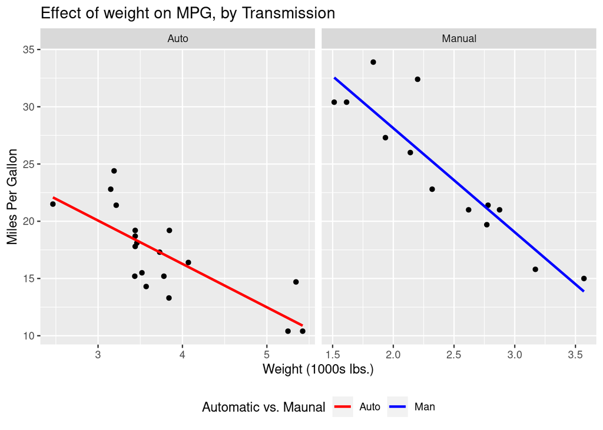

```r
mtcars %>%
   ggplot(aes(x = wt, y = mpg)) +
   geom_point() +
   geom_smooth(aes(col=as.factor(am)), method = 'lm', se = F) +
   facet_wrap(~am, scales = "free_x",
      labeller = labeller(
         am = c("0" = "Auto",
                "1" = "Manual")
      ) #for this call specficially, my indentation is non-standard
   ) +
   scale_color_manual(
      name = "Automatic vs. Maunal",
      values = c("red", "blue"),
      labels = c("Auto", "Man")
   ) +
   labs(
      title = "Effect of weight on MPG, by Transmission",
      x = "Weight (1000s lbs.)",
      y = "Miles Per Gallon"
   ) +
   theme(legend.position = "bottom")
```

### Colors in and out of `aes`

Compare the following code blocks and their respective outputs:

**Inside AES**

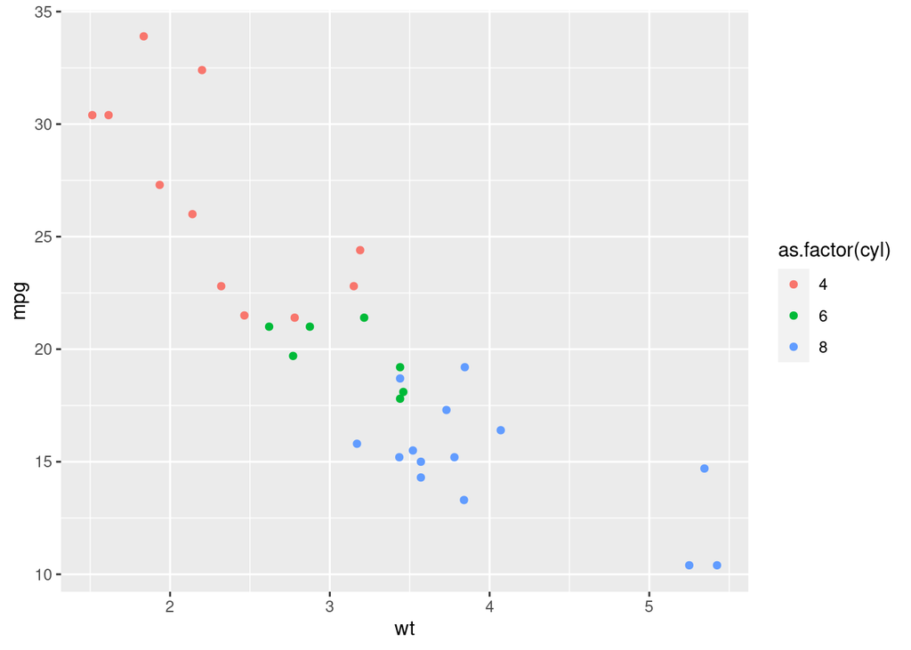

```r
mtcars %>%
   ggplot() +
   geom_point(aes(x = wt, y = mpg, col = as.factor(cyl)))
```

**Outside AES**

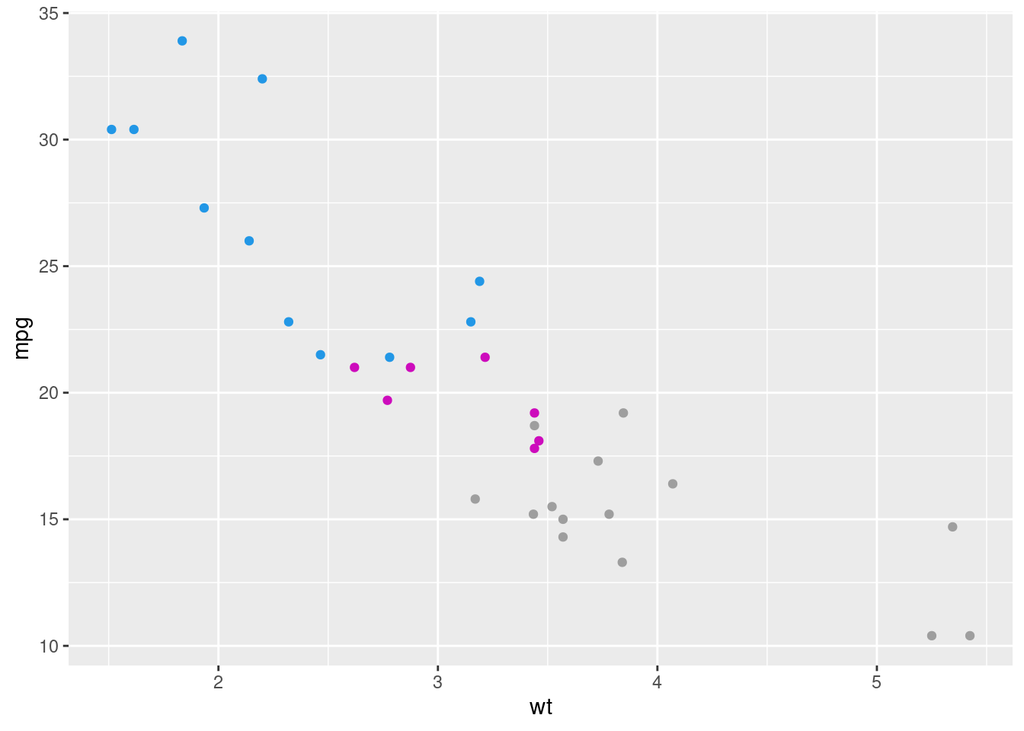

```r
mtcars %>%
   ggplot() +
   geom_point(aes(x = wt, y = mpg), col = mtcars$cyl)
```

- What I *don’t* want you to worry about is the color scale and the `as.factor` call
- What I **do** want you to notice:
  - Outside AES, `geom_point` doesn’t know what `cyl` is
    - Therefore, we have to call `mtcars` *again*[^2]
  - Outside AES, we don’t have a legend key
    - There is actually more to this than it may seem

#### Inside/Outside AES, Explained

- Crucially, when you put something in “aes”, it maps your varaible to a built-in “aesthetic” that `ggplot` knows.
- So, you can think of the colors, shapes, sizes, etc. inside `aes()` as their own layers/characteristics of the plot
- On the other hand, colors (etc.) *outside* `aes` can be thought of as low-level options that we told a `geom` to use
- This may seem minor right now. When you are on your own, make sure you are aware of whether things like `color`, `size`, `shape`, `fill` are inside or outside an `aes()` call